# Walkthrough Guide - Visualizations and Reporting in R

## 4.2 RMarkdown

R Markdown documents are fully reproducible. RStudio fully supports RMarkdown and provides an interface to weave together narrative text and code to produce elegantly formatted output.

You can make documents, interactive documents, dashboards, presentations, books, websites, and journal articles with built in templates.

A RMarkdown document has three parts, the header, text, and code.

To begin first open up a new RMarkdown, go to File -> New File -> R Markdown… This screen should pop up:

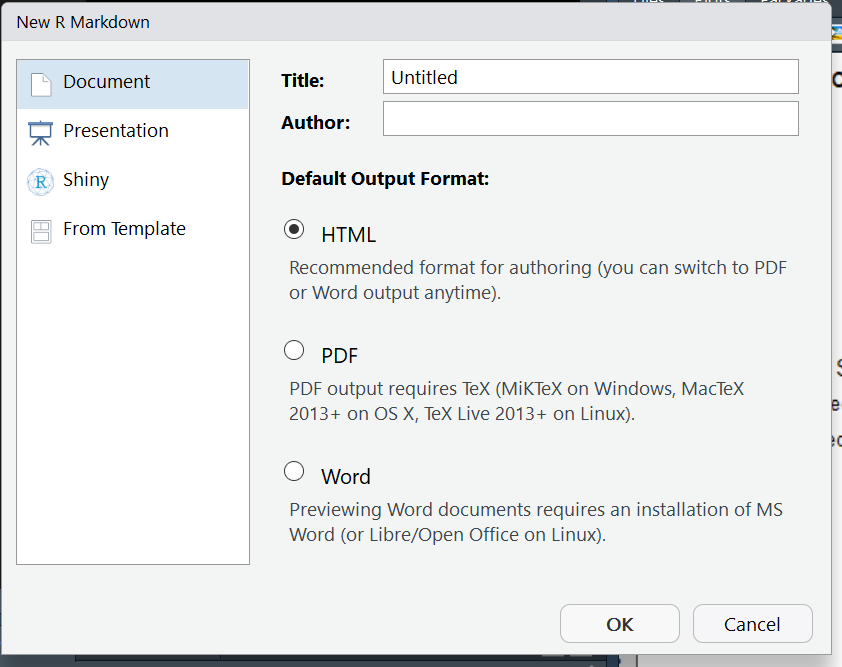

New RMarkdown Prompt

Go ahead and give your document a title and author, the default html is good (all three of these things you can change later) and then click OK

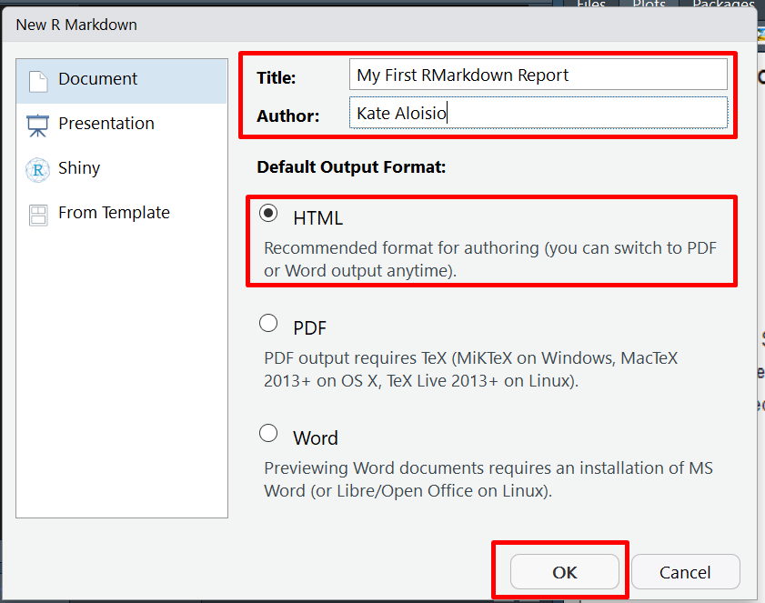

New RMarkdown Prompt Select

Then you should see RStudio’s default report.

[figure not shown]

Default report

The file has three main parts, the header:

[figure not shown]

Header

code chunks:

[figure not shown]

Code Chunk

and text:

[figure not shown]

Markdown text

You’ll see that you can add hyperlinks, tables, bold and other text types. To find out more go to Help -> Markdown Quick Reference

To compile the file click the knit icon:

[figure not shown]

Knit

Note that from this menu you could also knit to pdf (which requires LaTeX) or work (which requires Microsoft Word).

After you click knit to html, it will prompt you to save the file, you only have to do this once. The results will then appear in the viewer or you could open the file from your file explorer.

[figure not shown]

Viewer

You can also start from scratch. Go ahead and delete everything in the document.

[figure not shown]

Empty Document

Note that it is perfectly okay to knit an empty document. You can also knit the document without a header, it will just use it’s default settings.

Let’s add back in the header. Notice that you can even change the theme of your report to add that extra customization. Here we are using the readable theme.

[figure not shown]

Add a header

Most RMarkdown files will then have a setup chunk. This is where I like to library packages and read in data. By using the option `include = FALSE` we are ensuring that none of this chunk will appear in the report.

[figure not shown]

Add a setup

Now feel free to add some text and insert a code chunk for our plot 1.

You can insert a code chunk by clicking on the Insert button. Or you can use the shortcut ctrl+alt+i

[figure not shown]

Add a R chunk

Next, copy and paste p1 into this chunk. If we compiled the report as is, it would also include the code as seen below:

[figure not shown]

Compile with echo

This is gross. Include the option `echo = F` to prevent the code from appearing in the output.

[figure not shown]

Compile without echo

You can continue this process until your report is ready. Make sure you save your work and knit before closing your file.

In your materials is a more documented example of a completed report.

Now you have a document that you can share with the world and it is completely reproducible!